# CMSC6950 Homework #1

Isaac Adoboe - ieadoboe@mun.ca

Before I start the assignment, I created this python notebook and a images folder to store the screenshots for the assignments. Below is how the folder looks now.

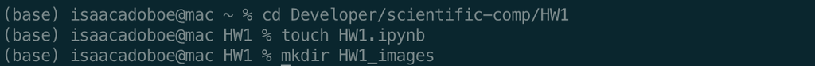

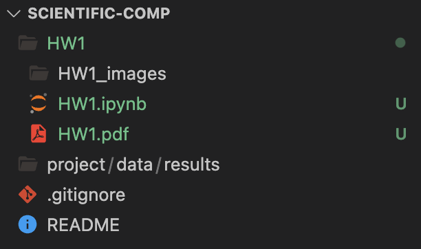

### Question 1

Make `isaac_CMSC6950` directory

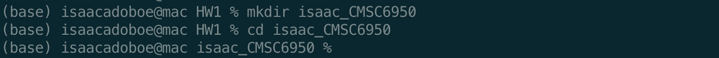

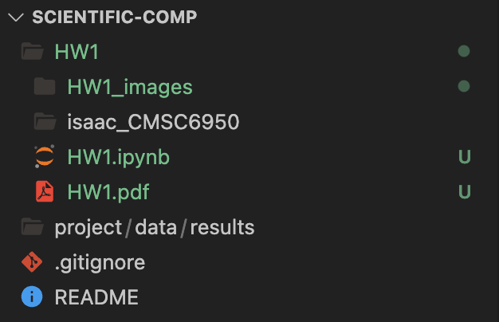

Create `202384695` text file

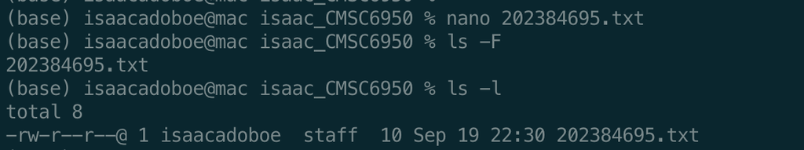

Show contents and change to home directory

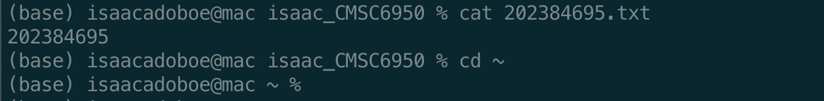

### Question 2

Create `copmutational_science.txt` and renaming it

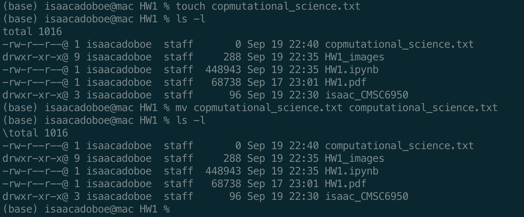

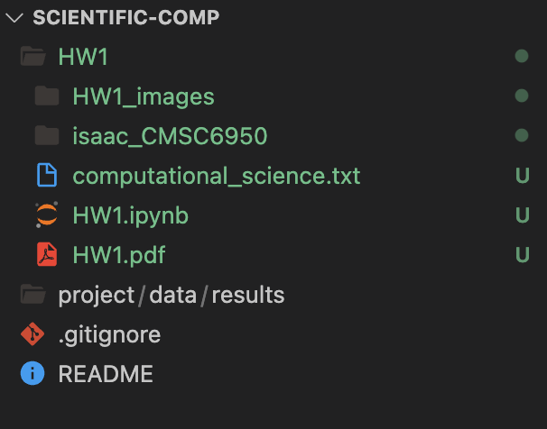

Remove `computational_science.txt` and create `copmutational_science.txt`

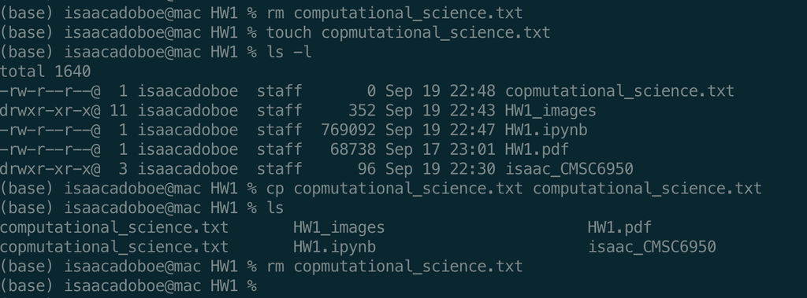

### Question 3

Before adding the `alkanes` folder

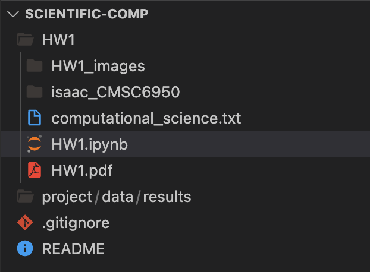

Copy `alkanes.zip` folder to working directory and unzipping

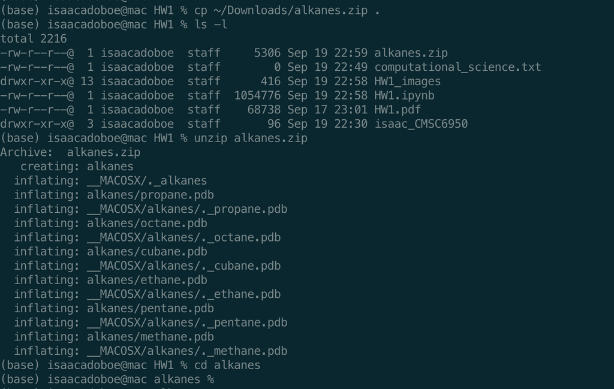

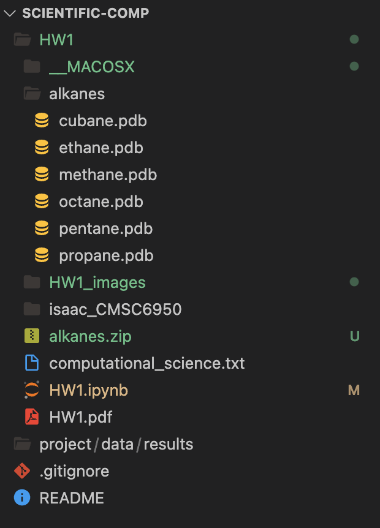

Total number of lines in all files

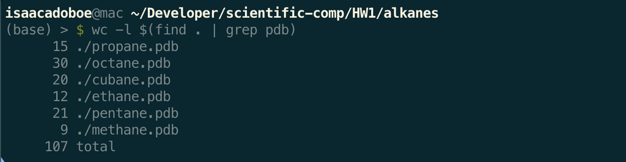

How many of the compounds have more than 6 atom’s listed in their file?

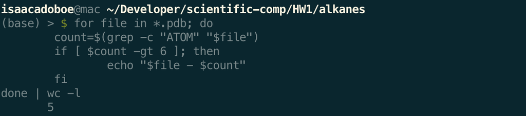

List the files in order of the decreasing number of lines.

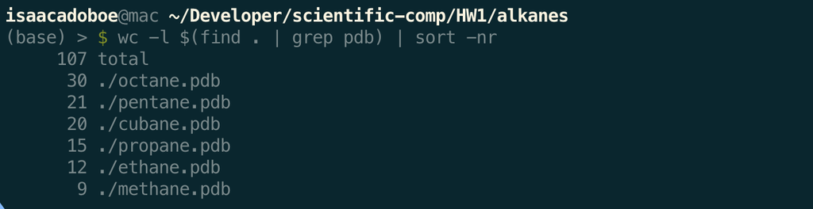

### Question 4

(a) Begin with either the word “Meg” or the word “Jo”

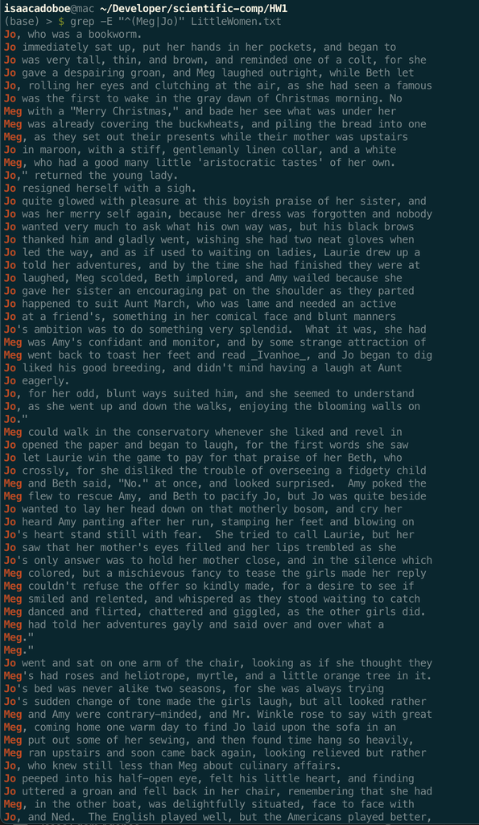

(b) Begin with the word “The” followed by a space

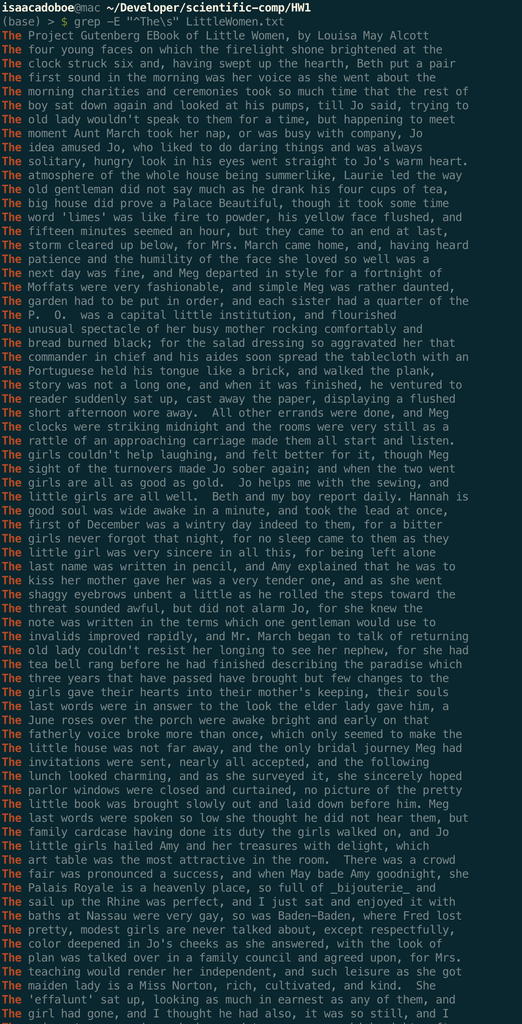

(c) Contain a word with any letter, followed by qu followed by exactly six more letters

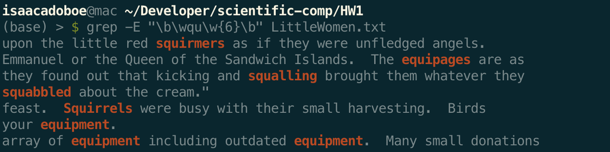

(d) Ends with either the word “time” or “times” followed by a period.

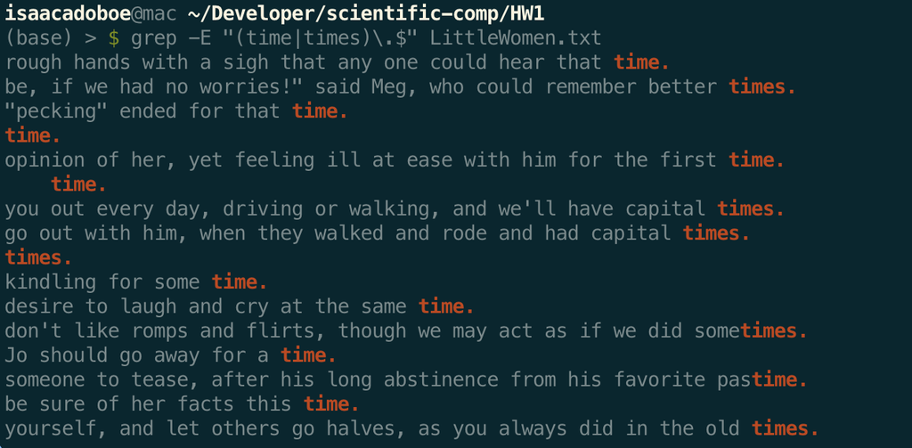